# Time Series: A First Course with Bootstrap Starter

# Lesson 7-1: Herglotz Theorem

We further study the relationship between autocovariance and spectral density.

## Example 7.1.2. Absolutely Summable Autocovariance.

- Suppose an ACVF $\{ \gamma (k) \}$ is absolutely summable, so that the spectral density $f$ exists.
- Define its anti-derivative, for $\lambda \in [-\pi,\pi]$:
  $$F(\lambda) = \int_{-\pi}^{\lambda} f(\omega) d\omega.$$
- So $F(-\pi) = 0$ and $F(\pi) = 2 \pi \gamma (0)$.
- $F$ is a bounded, non-decreasing, absolutely-continuous function. It is called the *spectral distribution*.
- With $dF (\lambda) = f(\lambda) d\lambda$, we can write
  $$\gamma (k) = \frac{1}{2 \pi} \int_{-\pi}^{\pi} e^{i \lambda k} dF
  (\lambda).$$
- This can be interpreted as a “Stieltjes integral” when $F$ is not differentiable.

## Example 7.1.4. Stochastic Cosine.

- Consider $X_t = A \cos (\vartheta t + \Phi)$, where $\Phi$ is uniformly distributed on $[0, 2 \pi]$, and $A$ has mean zero and variance $\sigma^2$. Also $\vartheta \in [0,\pi]$.
- The ACVF is $\gamma (k) = \sigma^2 \cos (\vartheta k)/2$, which is not summable, so the spectral density does not exist.
- However, we can choose $F$ such that the above relation still holds:
  $$F(\lambda) = \frac{ \sigma^2 \pi}{2} \, \left( 1_{ \{ \lambda \in
  [-\vartheta, \pi] \} }
  + 1_{ \{ \lambda \in [\vartheta, \pi ] \} } \right).$$

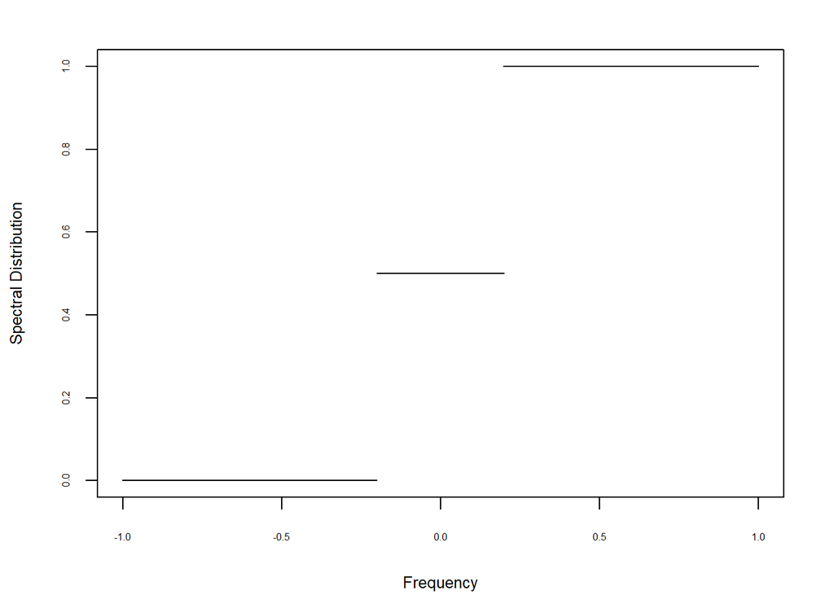

```r
theta <- pi/5
sig2 <- 1/pi
grid <- 1000
lambda <- pi*rep(0,grid+1)/grid
lambda <- c(rev(lambda),lambda[-1])
j <- grid*theta/pi
F.distr <- 0*cos(0*lambda)
F.distr[(grid+1-j):(grid+j)] <- .5*pi*sig2
F.distr[(grid+1+j):(2*grid+1)] <- pi*sig2
par(mar=c(4,4,2,2)+0.1,cex.lab=.8)
plot(ts(F.distr,start=-1,frequency=grid),xlab="Frequency",
    ylab="Spectral Distribution",yaxt="n",xaxt="n",type="points",pch=".")
axis(1,cex.axis=.5)
axis(2,cex.axis=.5)
```

## Definition 7.1.7.

- A function $F(\lambda)$ for $\lambda \in [-\pi,\pi]$ that is bounded, non-decreasing, and right continuous, and satisfies $F^{-} (\lambda) = F(\pi) - F(-\lambda)$ is called a **spectral distribution function.**
- $F^{-} (\lambda)$ is the left-hand limit.

## Theorem 7.1.8. Herglotz Theorem

A sequence $\{ \gamma (k) \}$ is an ACVF (non-negative definite with even symmetry) if and only if it can be written as
$$\gamma (k) = \frac{1}{2 \pi} \int_{-\pi}^{\pi} e^{i \lambda k} dF
(\lambda)$$
for some spectral distibution function $F$.

## Fact 7.1.9. Spectral Decomposition

- We can decompose a spectral distribution function $F$ into a singular portion $F_s$ and a absolutely continuous portion $F_c$:
  $$F = F_s + F_c.$$
- The absolutely continuous portion is differentiable almost everywhere, with derivative called the spectral density.
- The singular part corresponds to a step function.

## Exercise 7.5. Spectral Distribution of an ARMA Process.

- We write code to compute the spectral distribution $F$ of an ARMA process.
- We begin with the code for an ARMA spectral density.

```r
armapq.spec <- function(ar.coef,ma.coef,sigma,mesh)
{
    p <- length(ar.coef)
    q <- length(ma.coef)
    lambda <- pi*seq(0,mesh)/mesh
    spec.ar <- rep(1,mesh+1)
    if(p > 0)
    {
        for(k in 1:p)
        {
            spec.ar <- spec.ar - ar.coef[k]*exp(-1i*lambda*k)
        }
    }
    spec.ma <- rep(1,mesh+1)
    if(q > 0)
    {
        for(k in 1:q)
        {
            spec.ma <- spec.ma + ma.coef[k]*exp(-1i*lambda*k)
        }
    }
    spec <- sigma^2*Mod(spec.ma)^2/Mod(spec.ar)^2
    return(spec)
}
```

- Then we get the spectral distribution by numerical integration, via trapezoidal rule.

```r
armapq.distr <- function(ar.coef,ma.coef,sigma,mesh)
{

    f.spec <- armapq.spec(ar.coef,ma.coef,sigma,mesh)
    f.spec <- c(rev(f.spec),f.spec[-1])
    f.distr <- rep(0,2*mesh+1)
    for(i in 1:(2*mesh))
    {
        f.distr[i+1] <- f.distr[i] + (f.spec[i]+f.spec[i+1])/2
    }
    f.distr <- pi*f.distr/mesh
    return(f.distr)
}
```

- Then we apply this in the case of the cycle ARMA(2,1). We plot the spectral density and the spectral distribution.

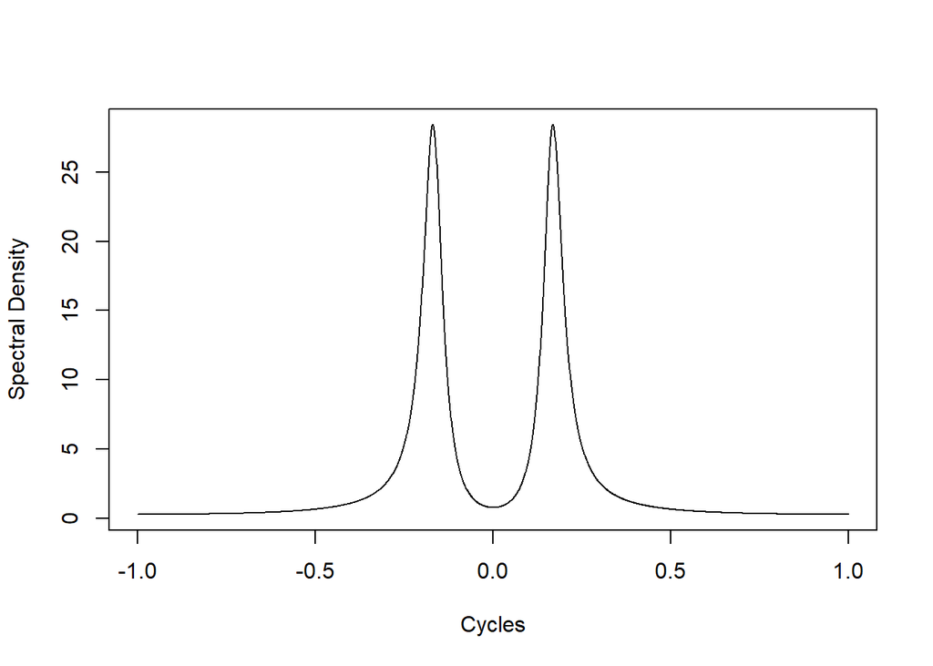

```r
mesh <- 1000
rho <- .9
omega <- pi/6
ar.coef <- c(2*rho*cos(omega),-1*rho^2)
ma.coef <- -1*rho*cos(omega)
spec <- armapq.spec(ar.coef,ma.coef,1,mesh)
plot(ts(c(rev(spec),spec[-1]),start=-1,frequency=mesh),xlab="Cycles",ylab="Spectral Density",main="")
```

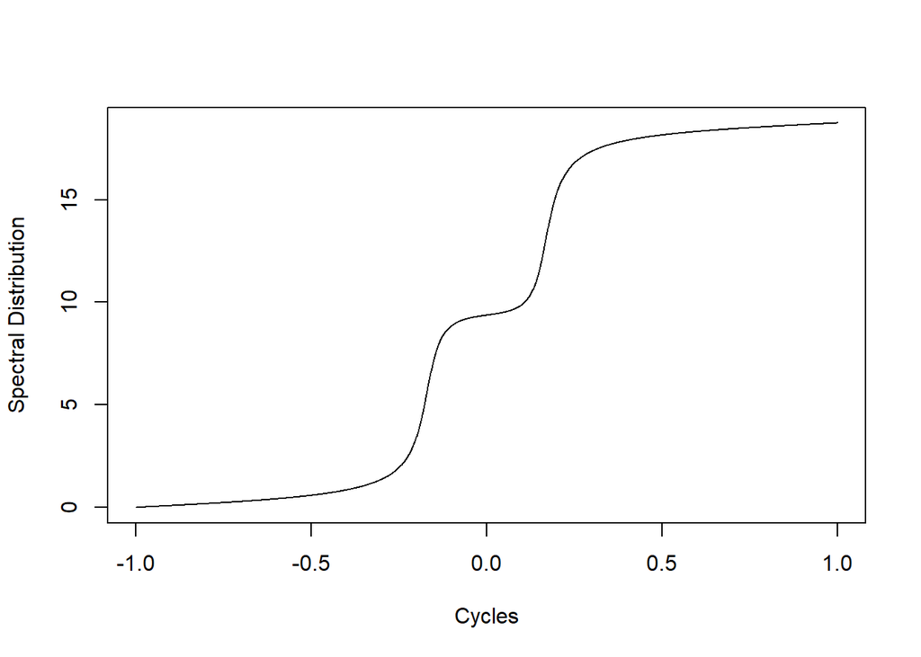

```r
spec <- armapq.distr(ar.coef,ma.coef,1,mesh)
plot(ts(spec,start=-1,frequency=mesh),xlab="Cycles",ylab="Spectral Distribution",main="")
```